# Mangrove Dispersion

### High Density: Low Tide

```r
favstats(Propagule_Data$DistanceTraveled.m[Propagule_Data$Zone== "1" & Propagule_Data$Density=="H" & Propagule_Data$Tide=="L"])
```

|  | min | Q1 | median | Q3 | max | mean | sd | n | missing |
| --- | --- | --- | --- | --- | --- | --- | --- | --- | --- |
|  | 39.6031 | 42.41406 | 44.44655 | 258.9193 | 338.7784 | 144.8323 | 143.4145 | 5 | 0 |

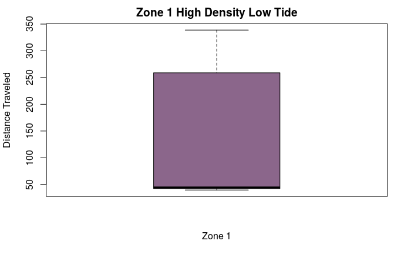

```r
boxplot(Propagule_Data$DistanceTraveled.m[Propagule_Data$Zone== "1" & Propagule_Data$Density=="H" & Propagule_Data$Tide=="L"], xlab = "Zone 1", ylab = "Distance Traveled", col = "plum4", main = "Zone 1 High Density Low Tide")
```

### Low Density: High Tide

```r
favstats(Propagule_Data$DistanceTraveled.m[Propagule_Data$Zone== "1" & Propagule_Data$Density=="L" & Propagule_Data$Tide=="H"])
```

|  | min | Q1 | median | Q3 | max | mean | sd | n | missing |
| --- | --- | --- | --- | --- | --- | --- | --- | --- | --- |
|  | 43.37254 | 93.07356 | 142.7746 | 245.0054 | 347.2363 | 177.7945 | 154.9293 | 3 | 0 |

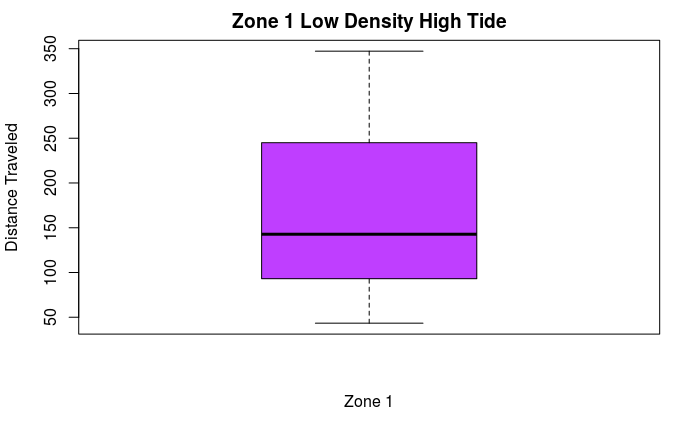

```r
boxplot(Propagule_Data$DistanceTraveled.m[Propagule_Data$Zone== "1" & Propagule_Data$Density=="L" & Propagule_Data$Tide=="H"], xlab = "Zone 1", ylab = "Distance Traveled", col = "darkorchid1", main = "Zone 1 Low Density High Tide")
```

### Low Density: Low Tide

```r
favstats(Propagule_Data$DistanceTraveled.m[Propagule_Data$Zone== "1" & Propagule_Data$Density=="L" & Propagule_Data$Tide=="L"])
```

|  | min | Q1 | median | Q3 | max | mean | sd | n | missing |
| --- | --- | --- | --- | --- | --- | --- | --- | --- | --- |
|  | 56.59661 | 56.59663 | 59.33896 | 119.5578 | 291.9872 | 116.8154 | 116.8098 | 4 | 0 |

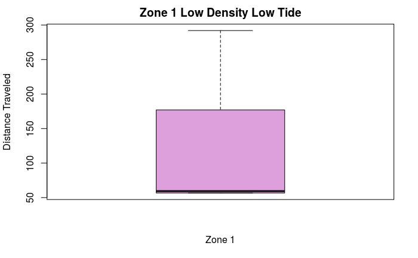

```r
boxplot(Propagule_Data$DistanceTraveled.m[Propagule_Data$Zone== "1" & Propagule_Data$Density=="L" & Propagule_Data$Tide=="L"], xlab = "Zone 1", ylab = "Distance Traveled", col = "plum", main = "Zone 1 Low Density Low Tide")
```

## Zone 2

### High Density: High Tide

```r
favstats(Propagule_Data$DistanceTraveled.m[Propagule_Data$Zone== "2" & Propagule_Data$Density=="H" & Propagule_Data$Tide=="H"])
```

|  | min | Q1 | median | Q3 | max | mean | sd | n | missing |
| --- | --- | --- | --- | --- | --- | --- | --- | --- | --- |
|  | 240.3073 | 258.3351 | 279.5071 | 290.2047 | 309.702 | 275.6786 | 25.72987 | 6 | 0 |

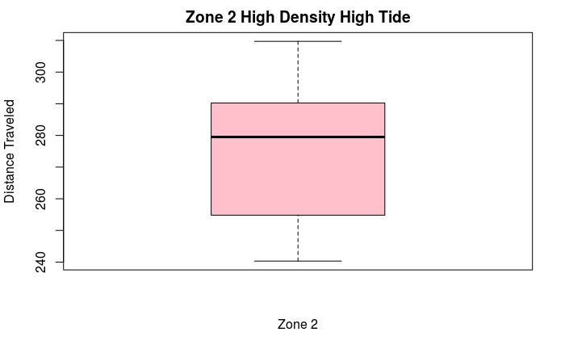

```r
boxplot(Propagule_Data$DistanceTraveled.m[Propagule_Data$Zone== "2" & Propagule_Data$Density=="H" & Propagule_Data$Tide=="H"], xlab = "Zone 2", ylab = "Distance Traveled", col = "pink", main = "Zone 2 High Density High Tide")
```

### High Density: Low Tide

```r
favstats(Propagule_Data$DistanceTraveled.m[Propagule_Data$Zone== "2" & Propagule_Data$Density=="H" & Propagule_Data$Tide=="L"])
```

|  | min | Q1 | median | Q3 | max | mean | sd | n | missing |
| --- | --- | --- | --- | --- | --- | --- | --- | --- | --- |
|  | 204.8744 | 251.4565 | 281.2862 | 313.1673 | 324.4038 | 277.116 | 44.62455 | 7 | 0 |

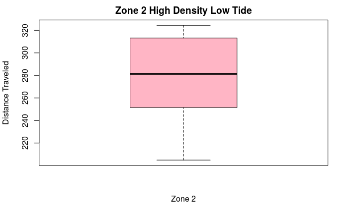

```r
boxplot(Propagule_Data$DistanceTraveled.m[Propagule_Data$Zone== "2" & Propagule_Data$Density=="H" & Propagule_Data$Tide=="L"], xlab = "Zone 2", ylab = "Distance Traveled", col = "pink1", main = "Zone 2 High Density Low Tide")
```

### Low Density: High Tide

```r
favstats(Propagule_Data$DistanceTraveled.m[Propagule_Data$Zone== "2" & Propagule_Data$Density=="L" & Propagule_Data$Tide=="H"])
```

|  | min | Q1 | median | Q3 | max | mean | sd | n | missing |
| --- | --- | --- | --- | --- | --- | --- | --- | --- | --- |
|  | 186.1064 | 248.4138 | 256.6555 | 280.1832 | 330.615 | 261.5101 | 45.54767 | 7 | 0 |

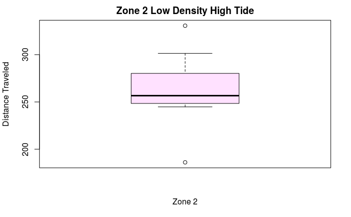

```r
boxplot(Propagule_Data$DistanceTraveled.m[Propagule_Data$Zone== "2" & Propagule_Data$Density=="L" & Propagule_Data$Tide=="H"], xlab = "Zone 2", ylab = "Distance Traveled", col = "thistle1", main = "Zone 2 Low Density High Tide")
```

### Low Density: Low Tide

```r
favstats(Propagule_Data$DistanceTraveled.m[Propagule_Data$Zone== "2" & Propagule_Data$Density=="L" & Propagule_Data$Tide=="L"])
```

|  | min | Q1 | median | Q3 | max | mean | sd | n | missing |
| --- | --- | --- | --- | --- | --- | --- | --- | --- | --- |
|  | 225.6218 | 253.6074 | 262.3158 | 266.3358 | 268.6895 | 256.2206 | 16.22025 | 6 | 0 |

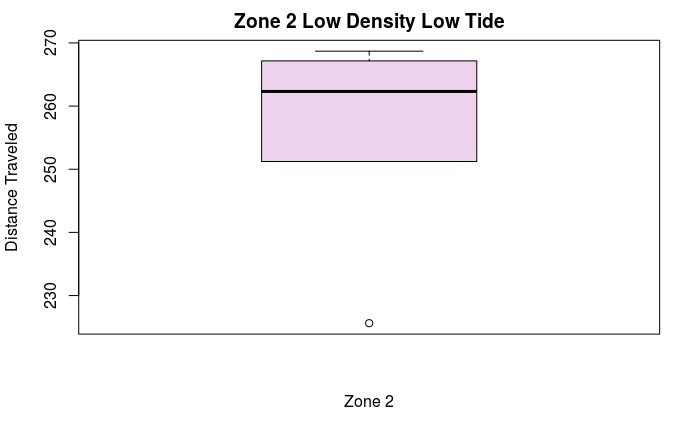

```r
boxplot(Propagule_Data$DistanceTraveled.m[Propagule_Data$Zone== "2" & Propagule_Data$Density=="L" & Propagule_Data$Tide=="L"], xlab = "Zone 2", ylab = "Distance Traveled", col = "thistle2", main = "Zone 2 Low Density Low Tide")
```

## Zone 3

### High Density: High Tide

```r
favstats(Propagule_Data$DistanceTraveled.m[Propagule_Data$Zone== "3" & Propagule_Data$Density=="H" & Propagule_Data$Tide=="H"])
```

|  | min | Q1 | median | Q3 | max | mean | sd | n | missing |
| --- | --- | --- | --- | --- | --- | --- | --- | --- | --- |
|  | 93.10635 | 100.5492 | 108.15 | 122.9259 | 137.9767 | 111.8842 | 15.63313 | 9 | 0 |

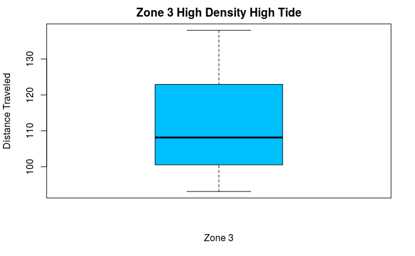

```r
boxplot(Propagule_Data$DistanceTraveled.m[Propagule_Data$Zone== "3" & Propagule_Data$Density=="H" & Propagule_Data$Tide=="H"], xlab = "Zone 3", ylab = "Distance Traveled", col = "deepskyblue1", main = "Zone 3 High Density High Tide")
```

### High Density: Low Tide

```r
favstats(Propagule_Data$DistanceTraveled.m[Propagule_Data$Zone== "3" & Propagule_Data$Density=="H" & Propagule_Data$Tide=="L"])
```

|  | min | Q1 | median | Q3 | max | mean | sd | n | missing |
| --- | --- | --- | --- | --- | --- | --- | --- | --- | --- |
|  | 84.91781 | 95.76261 | 106.3317 | 128.0235 | 136.833 | 110.3737 | 21.73381 | 5 | 0 |

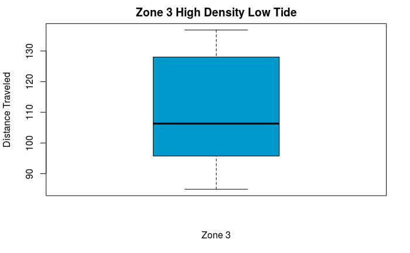

```r
boxplot(Propagule_Data$DistanceTraveled.m[Propagule_Data$Zone== "3" & Propagule_Data$Density=="H" & Propagule_Data$Tide=="L"], xlab = "Zone 3", ylab = "Distance Traveled", col = "deepskyblue3", main = "Zone 3 High Density Low Tide")
```

### Low Density: High Tide

```r
favstats(Propagule_Data$DistanceTraveled.m[Propagule_Data$Zone== "3" & Propagule_Data$Density=="L" & Propagule_Data$Tide=="H"])
```

|  | min | Q1 | median | Q3 | max | mean | sd | n | missing |
| --- | --- | --- | --- | --- | --- | --- | --- | --- | --- |
|  | 92.85389 | 95.18402 | 96.81623 | 109.4835 | 125.7084 | 104.0092 | 13.73761 | 5 | 0 |

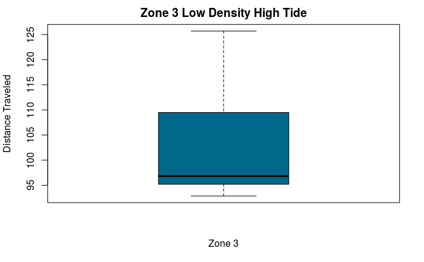

```r
boxplot(Propagule_Data$DistanceTraveled.m[Propagule_Data$Zone== "3" & Propagule_Data$Density=="L" & Propagule_Data$Tide=="H"], xlab = "Zone 3", ylab = "Distance Traveled", col = "deepskyblue4", main = "Zone 3 Low Density High Tide")
```